# Estimation of Pi using Monte Carlo Simulation

Trelan Hakkem-Barron

4/18/2020

For this project, I will be show you how to use the Mnte Carlo Method to simulate the estimation of Pi. As we know, if r is the radius of a circle, then the surface of this circle is PI * r * r. Therefore, if we know the radius of a circle, and if we can estimate the surface of this circle, we can estimate PI. We know that the math constant Pi can be approximated by 4 times of the number of points inside a circle divided by the total number of points. How can we estimate the surface of a circle with a random method. The answer is found in the square!

To show the simulation, I will be generating a large number of random points and see how many fall in the circle enclosed by the unit square. The points inside the circle will be shown in black. The points outside the circle will be shown in blue.

# The Use of 100 Darts

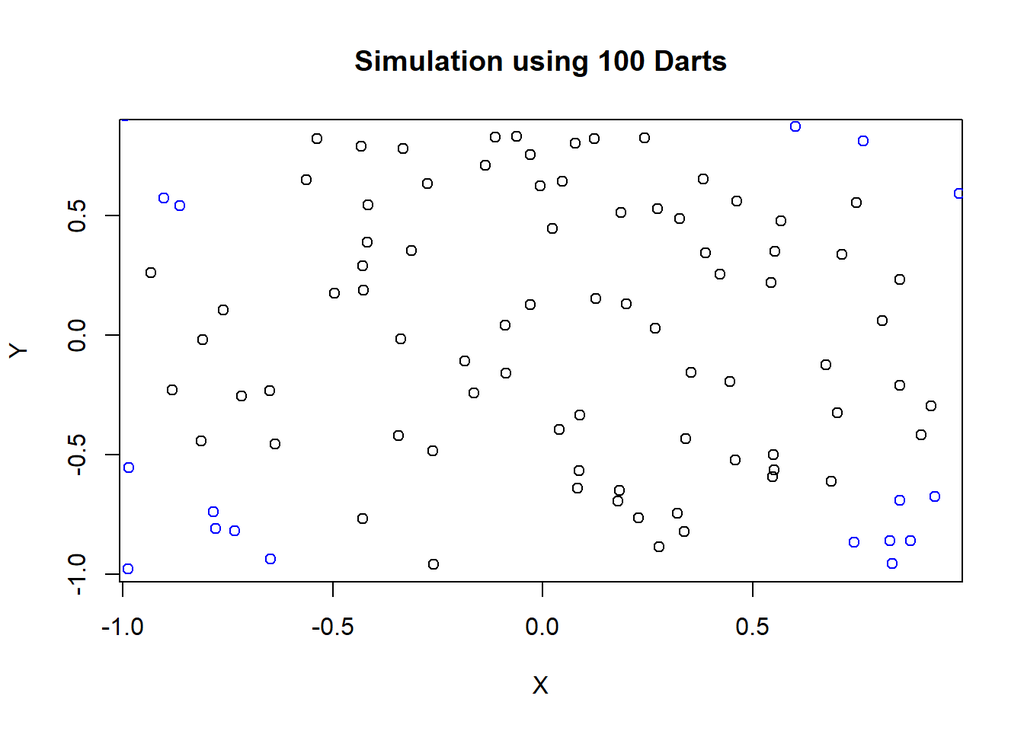

```
## [1] 3.16
```

# The Use of 1,000 Darts

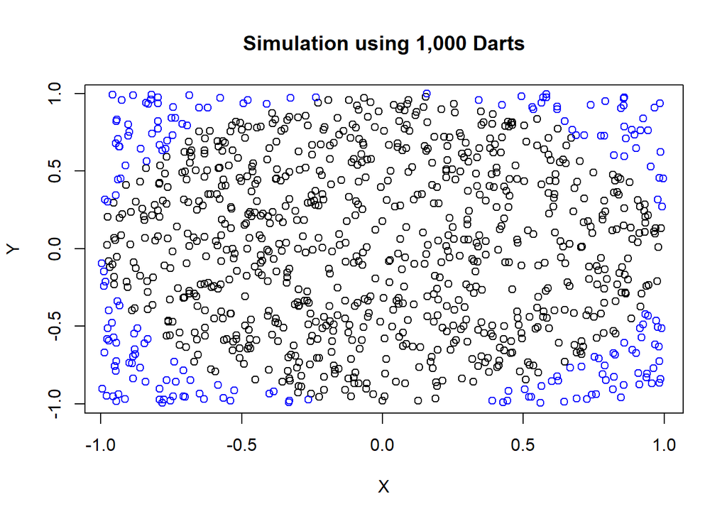

```
## [1] 3.192
```

# The Use of 10,000 Darts

Now this is really good. The appproximation of pi is looking good as well. I think we can try this one more time for a better picture overall. Let’s try with 100,000 darts this time.

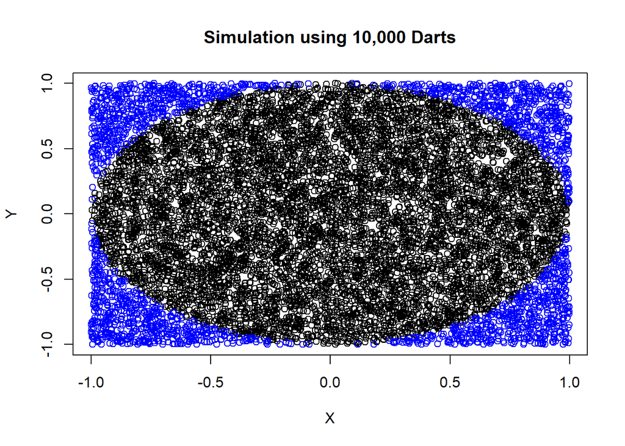

```
## [1] 3.1292
```

# The Use of 100,000 Darts

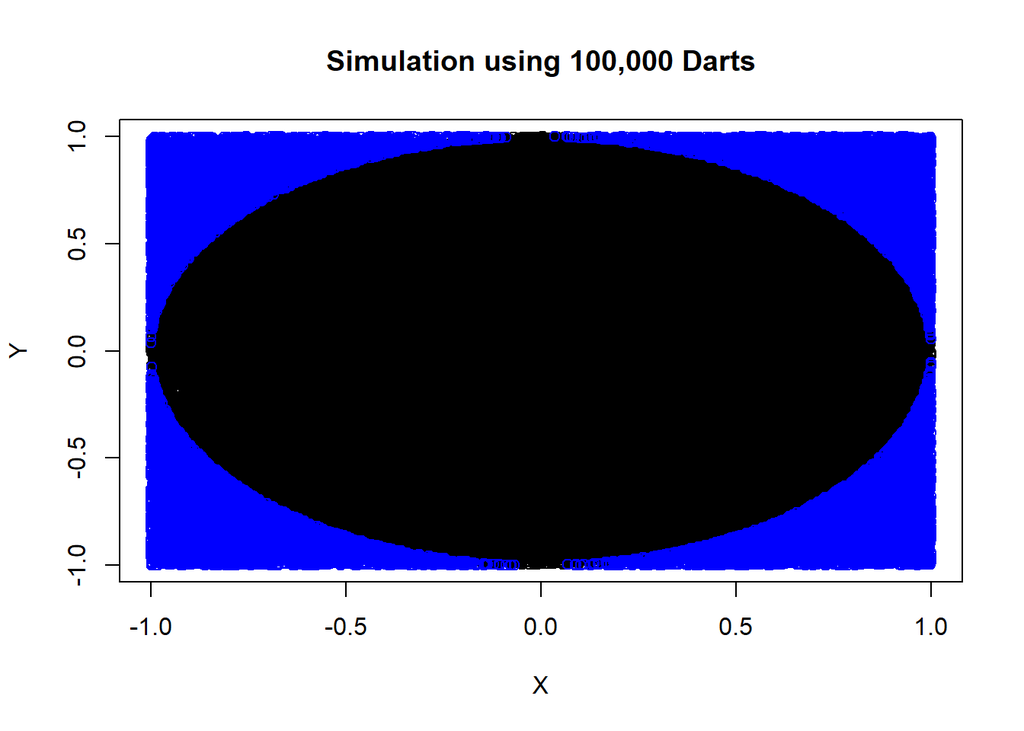

```
## [1] 3.14096
```